# Callaway & Sant’Anna Difference in Difference Analysis for a Staggered Treatment

Isaiah Lyons-Galante

Now that we have extract nighttime lights values from the previous notebook, we are ready for modeling. We will compare the mini-grid sites to the dark area sites using a Difference in Difference analysis for staggered treatment timing. We will use the Callaway & Sant’Anna (2020) Difference in Difference analysis for a staggered treatment. The original paper can be found [here](https://www.sciencedirect.com/science/article/pii/S0304407620300253). An online tutorial can be found [here](https://tilburgsciencehub.com/topics/analyze/causal-inference/did/staggered-did/).

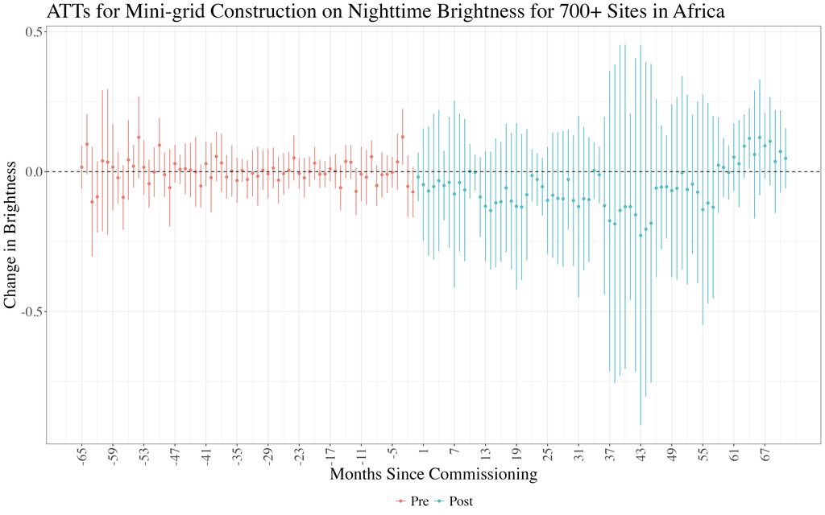

did-example

## Table of Contents

- Overview
- Data Preparation
  - Load Packages
  - Read in the Dark Area Data
  - Read in the Mini-Grid Data
  - Merge the Dark Area and Mini-Grid Data
  - Melt the Dataset
- Exploratory Analysis
  - Visualize Raw Data
  - Look at Variances
  - Outliers
- Difference in Difference Analysis
  - Data Requirements
  - Create a Treatment Group Variable
  - Run the Analysis
  - Aggregated Results
- Results
- Interpretation and Conclusions
- Further Reading

## Load Packages

```r
library(tidyverse)
library(did)
library(lubridate)
library(sf)
```

## Read in the Dark Area Data, Clean, Re-export

```r
# read in data
africa_dark_df <- read_csv("data/dark_africa/nighttime_dark_gdf.csv")
```

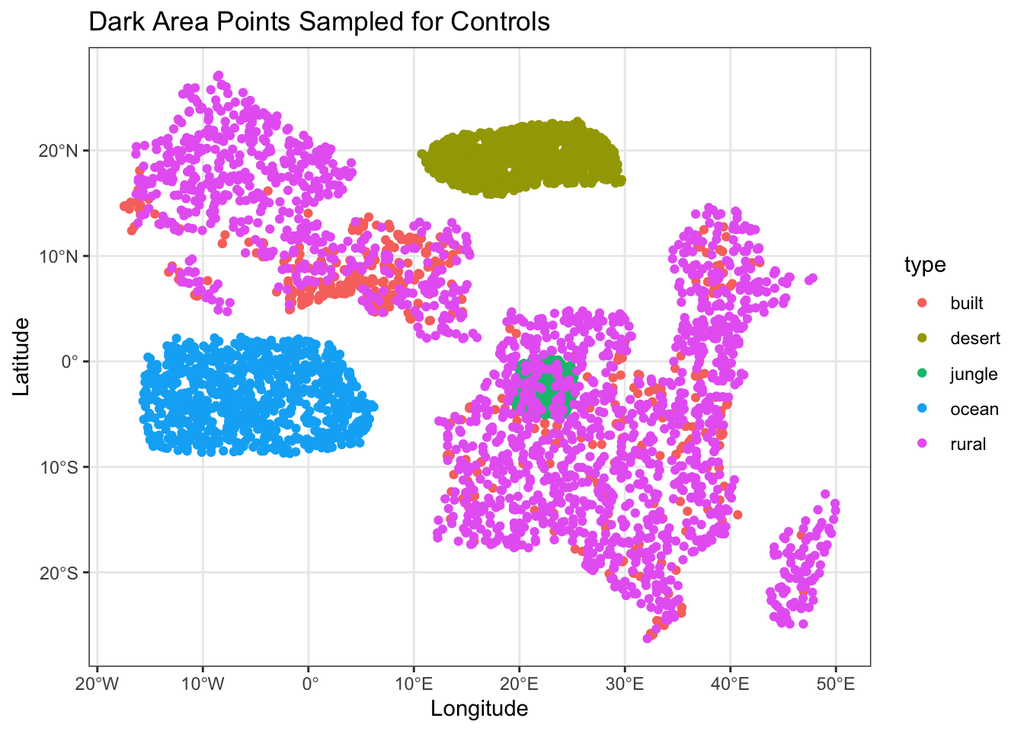

```r
# convert to sf
africa_dark_sf <- st_as_sf(africa_dark_df, wkt = "geometry", crs = 4326)

# add a column date_commissioned equal to December 1, 2013
africa_dark_sf <- africa_dark_sf %>%
    mutate(date_commissioned = as.Date("2013-12-01"))

# glimpse
# glimpse(africa_dark_sf)

# visualize the sf with ggplot geom_sf with different colors for type
ggplot(africa_dark_sf) +
    geom_sf(aes(color = type)) +
    labs(title = "Dark Area Points Sampled for Controls", x = "Longitude", y = "Latitude") +
    theme_bw()
```

```r
# export sf
saveRDS(africa_dark_sf, "data/dark_africa/africa_dark_sf.rds")
```

## Read in the Mini-Grid Data

```r
# read in data
africa_minigrid_df <- read_csv("data/cluber/nighttime_cluber_gdf.csv")
```

```
## ──────────────────────────────────────────────────────── Delimiter: "," chr
## (6): geometry, country, developer, site_name, source, status dbl (123): ...1,
## 20140101, 20140201, 20140301, 20140401, 20140501, 20140601... date (1):
## date_commissioned
```

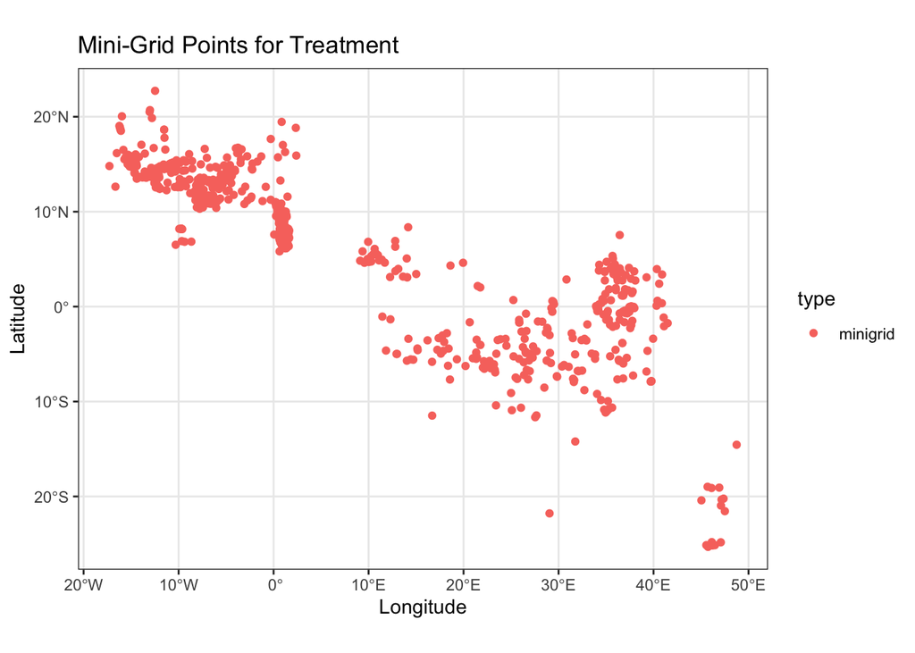

```r
# glimpse(africa_minigrid_df)

# convert to sf with latitude and longitude columns into geometry
africa_minigrid_sf <- st_as_sf(africa_minigrid_df, coords = c("longitude", "latitude"), crs = 4326)

# glimpse(africa_minigrid_sf)
# drop the columns country, customers, developer, site_name, source, and status
africa_minigrid_sf <- africa_minigrid_sf %>%
    select(-country, -customers, -developer, -site_name, -source, -status)

# add a column "type" with value "minigrid"
africa_minigrid_sf <- africa_minigrid_sf %>%
    mutate(type = "minigrid")

# visualize the sf with ggplot geom_sf with different colors for type
ggplot(africa_minigrid_sf) +
    geom_sf(aes(color = type)) +
    labs(title = "Mini-Grid Points for Treatment", x = "Longitude", y = "Latitude") +
    theme_bw()
```

```r
# export sf
saveRDS(africa_minigrid_sf, "data/dark_africa/africa_minigrid_sf.rds")
```

## Merge the Dark Area and Mini-Grid Data

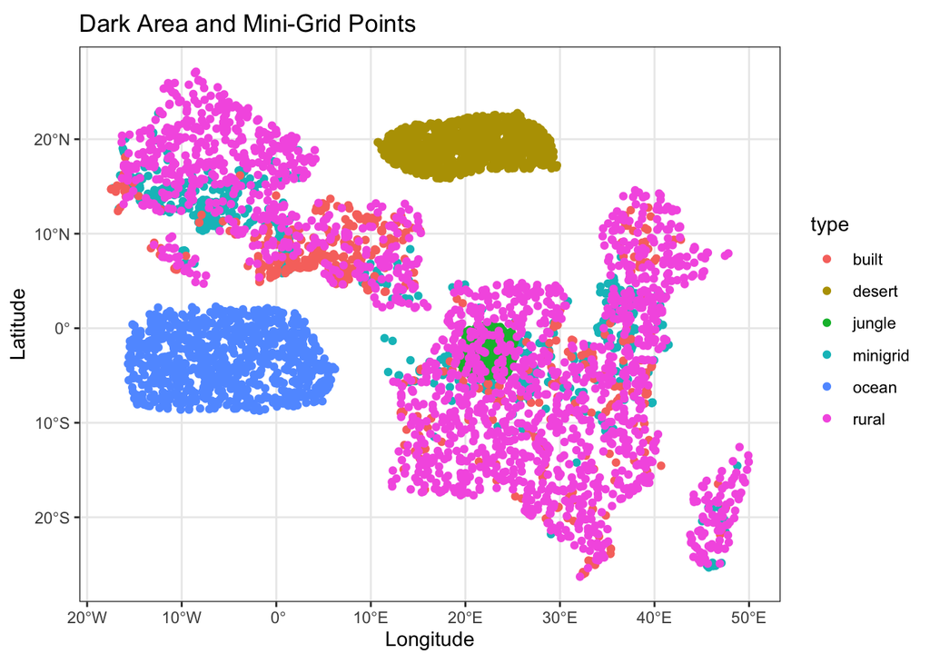

```r
# read in the 2 sfs
africa_dark_sf <- readRDS("data/dark_africa/africa_dark_sf.rds")
africa_minigrid_sf <- readRDS("data/dark_africa/africa_minigrid_sf.rds")
# glimpse(africa_minigrid_sf)
# merge the dfs
africa_sf <- bind_rows(africa_minigrid_sf, africa_dark_sf)
# glimpse(africa_sf)
rm(africa_minigrid_sf, africa_dark_sf)

# rename Map to landcover
africa_sf <- africa_sf %>%
    mutate(landcover = as.factor(Map))
# drop Map column
africa_sf <- africa_sf %>%
    select(-Map)
# set type to factor
africa_sf$type <- as.factor(africa_sf$type)

# drop the first column ...1
africa_sf <- africa_sf %>%
    select(-1)
# create an id column with an integer for each row
africa_sf <- africa_sf %>%
    mutate(id = as.factor(as.integer(row_number())))

# glimpse(africa_sf)

# visualize the sf with ggplot geom_sf with different colors for type
ggplot(africa_sf) +
    geom_sf(aes(color = type)) +
    labs(title = "Dark Area and Mini-Grid Points", x = "Longitude", y = "Latitude") +
    theme_bw()
```

```r
# export combined sf
saveRDS(africa_sf, "data/dark_africa/africa_sf.rds")
```

## Melt the Dataset

```r
# read in the sf
africa_sf <- readRDS("data/dark_africa/africa_sf.rds")

# convert to df without geometry
africa_df <- st_drop_geometry(africa_sf)
rm(africa_sf)

# melt the df, keep the date_commissioned, type, landcover, and id columns
africa_df_melt <- africa_df %>%
    pivot_longer(cols = c(-date_commissioned, -type, -landcover, -id), names_to = "image_date", values_to = "image_value")
rm(africa_df)
# add dashes to the image_date column instead of 20140101 to 2014-01-01
africa_df_melt <- africa_df_melt %>%
    mutate(image_date = str_replace(image_date, "(\\d{4})(\\d{2})(\\d{2})", "\\1-\\2-\\3"))

# convert image_date to date
africa_df_melt$image_date <- as.Date(africa_df_melt$image_date)

# glimpse
# glimpse(africa_df_melt)

# export df to csv
write_csv(africa_df_melt, "data/dark_africa/africa_df_melt.csv")
# export sf to rds
saveRDS(africa_df_melt, "data/dark_africa/africa_df_melt.rds")
```

## Visualize Raw Data

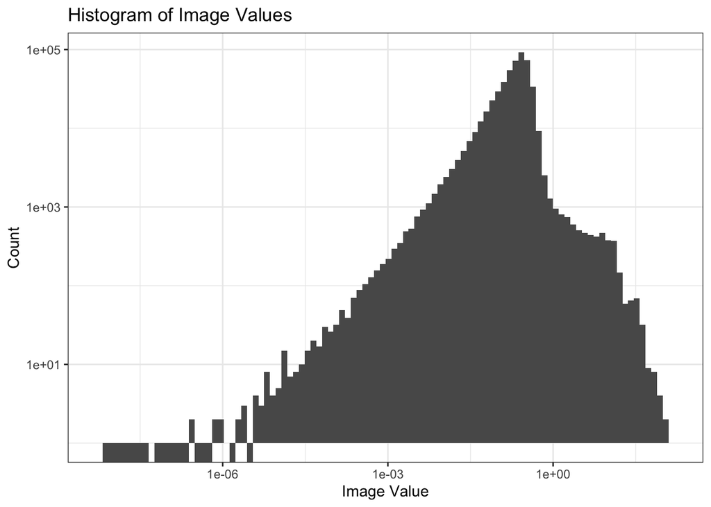

```r
# read in data
africa_df_melt <- readRDS("data/dark_africa/africa_df_melt.rds")
# glimpse(africa_df_melt)

# # exclude type "built"
africa_df_melt <- africa_df_melt %>%
    filter(type != "built")

# # exclude type "minigrid"
# africa_df_melt <- africa_df_melt %>%
#     filter(type != "minigrid")

# plot a histogram of image values with log(x) and log(y) scale
# color by log(x) in a linear scale
africa_df_melt %>%
    ggplot(aes(x = image_value)) +
    geom_histogram(bins = 100) +
    scale_x_log10() +
    scale_y_log10() +
    labs(title = "Histogram of Image Values", x = "Image Value", y = "Count") +
    theme_bw()
```

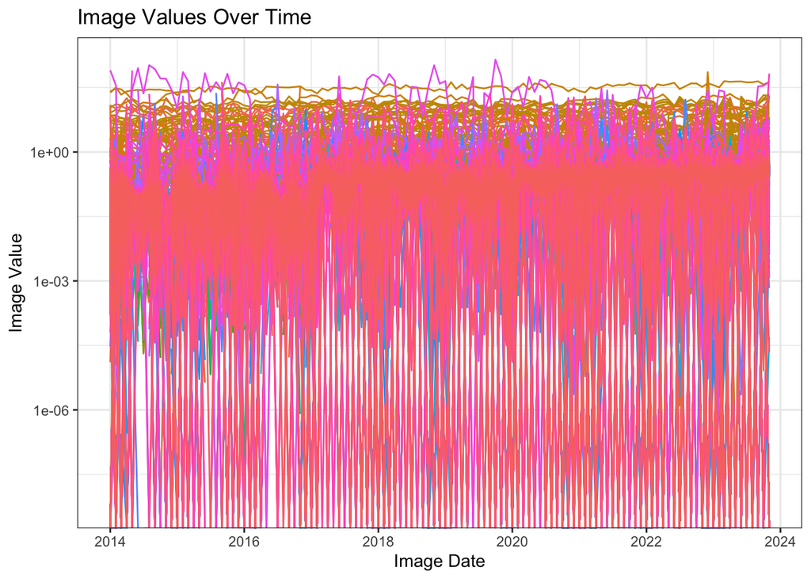

```r
# create a line plot of image values over time colored by id
africa_df_melt %>%
    ggplot(aes(x = image_date, y = image_value, color = id)) +
    geom_line() +
    labs(title = "Image Values Over Time", x = "Image Date", y = "Image Value") +
    theme_bw() +
    scale_y_log10()+
    # hide legend
    theme(legend.position = "none")
```

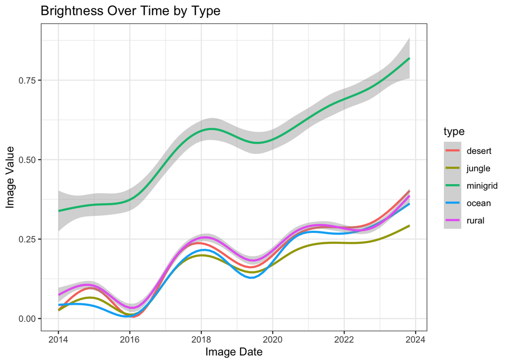

```r
# create a smooth plot of image values by over time colored by type
africa_df_melt %>%
    ggplot(aes(x = image_date, y = image_value, color = type)) +
    geom_smooth() +
    labs(title = "Brightness Over Time by Type", x = "Image Date", y = "Image Value") +
    theme_bw()
```

## Look at Variances

```r
# read in data
africa_df_melt <- readRDS("data/dark_africa/africa_df_melt.rds")
africa_df <- africa_df_melt

# calculate the standard deviation of all data points
sd_all <- sd(africa_df$image_value)
mean_all <- mean(africa_df$image_value)
min_all <- min(africa_df$image_value)
max_all <- max(africa_df$image_value)
median_all <- median(africa_df$image_value)

# calculate the standard deviation by type
africa_df_stats <- africa_df %>%
    group_by(type) %>%
    summarize(
        sd = sd(image_value),
        mean = mean(image_value),
        min = min(image_value),
        max = max(image_value),
        median = median(image_value)
    )

print(africa_df_stats)
```

```
## # A tibble: 6 × 6
##   type        sd  mean    min     max median
##   <fct>    <dbl> <dbl>  <dbl>   <dbl>  <dbl>
## 1 built    8.31  5.29  -0.248 280.     2.18
## 2 desert   0.126 0.193 -0.392   0.592  0.206
## 3 jungle   0.151 0.158 -0.460   4.05   0.151
## 4 minigrid 1.96  0.555 -0.413  72.3    0.235
## 5 ocean    0.143 0.172 -0.349   1.03   0.172
## 6 rural    0.960 0.203 -0.490 141.     0.181
```

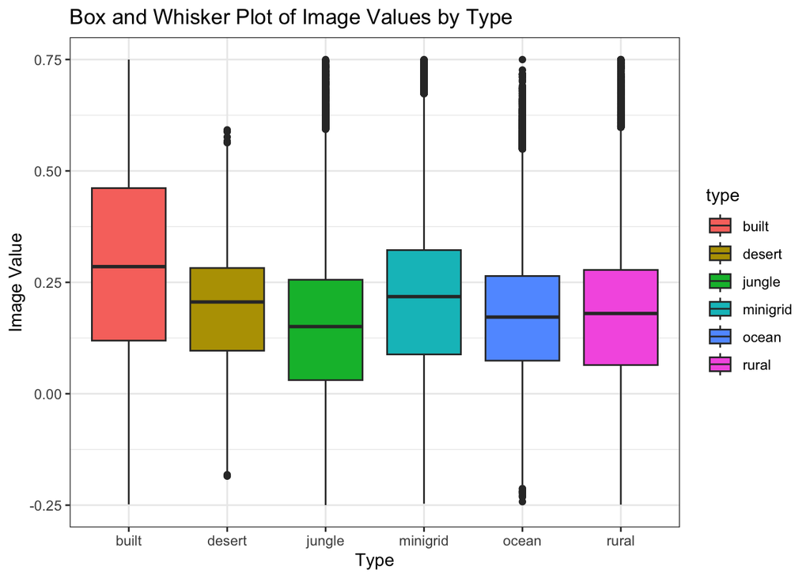

```r
# visualize as box and whisker plot
africa_df %>%
    ggplot(aes(x = type, y = image_value, fill = type)) +
    geom_boxplot() +
    labs(title = "Box and Whisker Plot of Image Values by Type", x = "Type", y = "Image Value") +
    # set ylim to -1, 3
    ylim(-0.25, 0.75) +
    theme_bw()
```

# Outliers

## Import Data & Calculate Medians & IQRs by ID

```r
# read in data
africa_df_melt <- readRDS("data/dark_africa/africa_df_melt.rds")
# glimpse(africa_df_melt)
df <- africa_df_melt

# find the median for each id, put it into a new column
df$median <- ave(df$image_value, df$id, FUN = median)
# find the upper 75% quartile for each id, put it into a new column
df$q3 <- ave(df$image_value, df$id, FUN = function(x) quantile(x, 0.75))
# find the lower 25% quartile for each id, put it into a new column
df$q1 <- ave(df$image_value, df$id, FUN = function(x) quantile(x, 0.25))
# calculate the IQR for each id, put it into a new column
df$IQR <- df$q3 - df$q1
# calculate the top whisker for each id, put it into a new column
df$top_whisker <- df$q3 + 1.5 * df$IQR
# calculate the bottom whisker for each id, put it into a new column
df$bottom_whisker <- df$q1 - 1.5 * df$IQR

# glimpse(df)

# convert any image_value that is above the top whisker to the top whisker
df <- df %>%
    mutate(image_value = ifelse(image_value > top_whisker, top_whisker, image_value))
# convert any image_value that is below the bottom whisker to the bottom whisker
df <- df %>%
    mutate(image_value = ifelse(image_value < bottom_whisker, bottom_whisker, image_value))

# drop the columns median, q1, q3, IQR, top_whisker, and bottom_whisker
df <- df %>%
    select(-median, -q1, -q3, -IQR, -top_whisker, -bottom_whisker)

# export
saveRDS(df, "data/dark_africa/africa_df_melt_clean.rds")
```

## Re-visualize Data After Cleaning Outliers

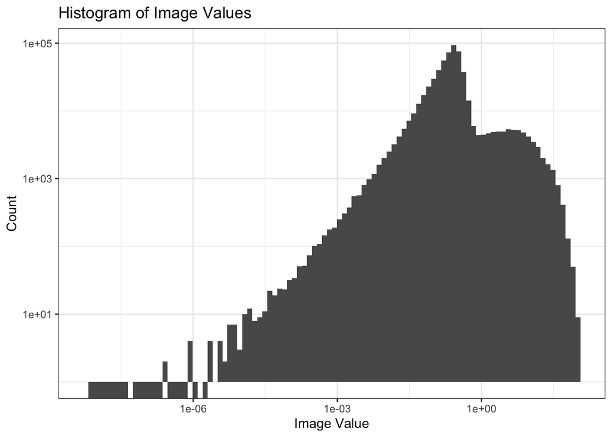

```r
# read in data
africa_df_melt_clean <- readRDS("data/dark_africa/africa_df_melt_clean.rds")
df <- africa_df_melt_clean

# plot a histogram of image values with log(x) and log(y) scale
# color by log(x) in a linear scale
df %>%
    ggplot(aes(x = image_value)) +
    geom_histogram(bins = 100) +
    scale_x_log10() +
    scale_y_log10() +
    labs(title = "Histogram of Image Values", x = "Image Value", y = "Count") +
    theme_bw()
```

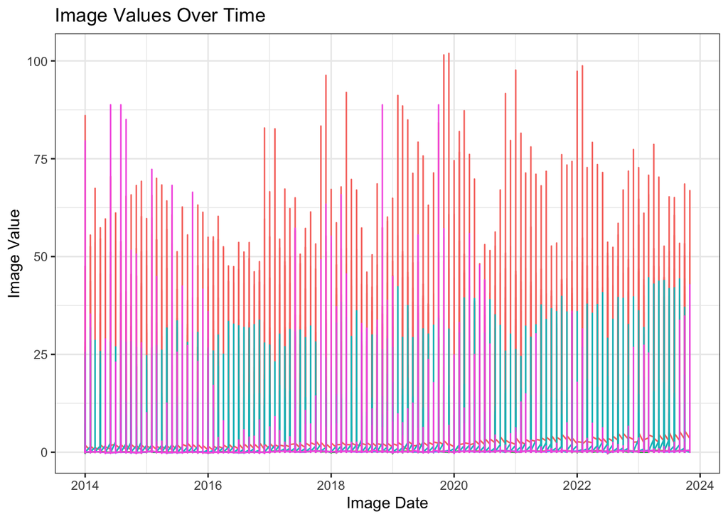

```r
# create a line plot of image values over time colored by id
df %>%
    ggplot(aes(x = image_date, y = image_value, color = type)) +
    geom_line() +
    labs(title = "Image Values Over Time", x = "Image Date", y = "Image Value") +
    theme_bw() +
    # hide legend
    theme(legend.position = "none")
```

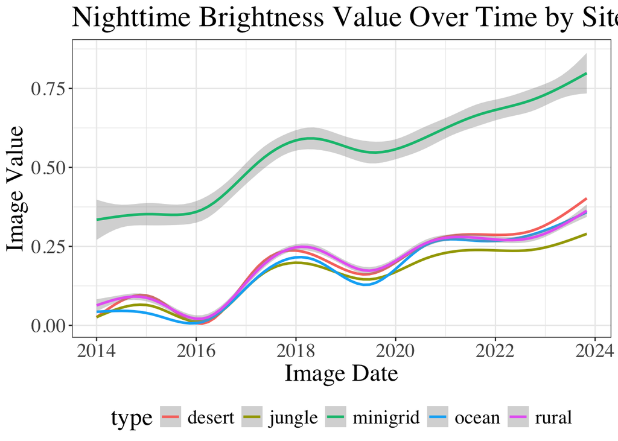

```r
# plot the data with geom_smooth
dark_smooth_plot <- df %>%
    filter(type != "built") %>%
    ggplot(aes(x = image_date, y = image_value, color = type)) +
    geom_smooth() +
    labs(title = "Nighttime Brightness Value Over Time by Site Type for CLUB-ER Sites", x = "Image Date", y = "Image Value") +
    theme_bw() +
    theme(text = element_text(size = 20, family = "serif")) +
    theme(legend.position = "bottom")
dark_smooth_plot
```

```r
ggsave("figures/dark_africa/dark_smooth_plot.png", dark_smooth_plot, width = 16, height = 8, units = "in", dpi = 300)
```

# Difference in Difference Analysis

## Create a Treatment Group Variable

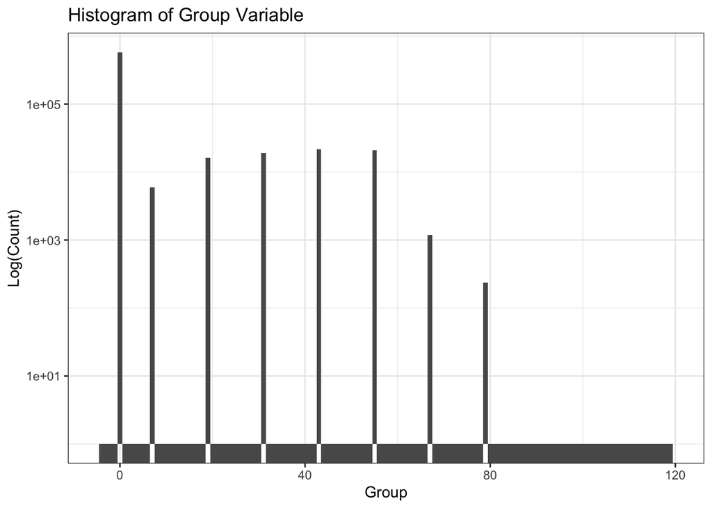

```r
# read in data
africa_df_melt_clean <- readRDS("data/dark_africa/africa_df_melt_clean.rds")
df <- africa_df_melt_clean

# glimpse(df)

# pull out the earliest date
start_date <- min(df$image_date)
end_date <- max(df$image_date)
start_year <- year(start_date)
end_year <- year(end_date)
start_month <- month(start_date)
end_month <- month(end_date)

# try the years
df$year_commissioned <- year(df$date_commissioned)
df$year_image <- year(df$image_date)

# extract months
df$month_commissioned <- month(df$date_commissioned)
df$month_image <- month(df$image_date)

# convert dates into months since first image
df$group <- (df$year_commissioned - start_year) * 12 + (df$month_commissioned - start_month) + 1 # 1 indexed
df$time_period <- (df$year_image - start_year) * 12 + (df$month_image - start_month) + 1 # 1 indexed

# convert id to numeric
df$id <- as.numeric(df$id)

# plot histogram of group variable
ggplot(df, aes(x = group)) +
    geom_histogram(binwidth = 1) +
    xlim(-5, 120) +
    scale_y_log10() +
    labs(title = "Histogram of Group Variable", x = "Group", y = "Log(Count)") +
    theme_bw()
```

```r
# export df to csv
# View(df)
saveRDS(df, "data/dark_africa/africa_df_melt_clean_for_csdind.rds")
```

## Run the Analysis

```r
# read in the data
africa_df_melt_clean_for_csdind <- readRDS("data/dark_africa/africa_df_melt_clean_for_csdind.rds")
df <- africa_df_melt_clean_for_csdind

# keep only types minigrid and control group, whichever that is
df <- df %>%
    filter(type == "minigrid" | type == "rural")

# add 72 to every group variable for minigrid
df$group <- ifelse(df$type == "minigrid", df$group + 72, df$group)

# run the model
# https://bcallaway11.github.io/did/reference/att_gt.html
did_control <- att_gt(
    yname = "image_value", # outcome variable
    tname = "time_period", # time variable
    idname = "id", # id variable
    gname = "group", # first treatment period variable
    data = df, # data
    control_group = "nevertreated", # set the comparison group as either "never treated" or "not yet treated"
)

# export the model results
saveRDS(did_control, "data/dark_africa/did_control_minigrid_rural_lag72.rds")

# aggregate the results
did_control_agg <- aggte(
    did_control,
    type = "dynamic",
    na.rm = TRUE
)

# export the results
saveRDS(did_control_agg, "data/dark_africa/did_control_agg_minigrid_rural_lag72.rds")

# read in the did model results
did_control_agg <- readRDS("data/dark_africa/did_control_agg_minigrid_rural_lag72.rds")

# view the results
summary(did_control_agg)
```

```
##
## Call:
## aggte(MP = did_control, type = "dynamic", na.rm = TRUE)
##
## Reference: Callaway, Brantly and Pedro H.C. Sant'Anna.  "Difference-in-Differences with Multiple Time Periods." Journal of Econometrics, Vol. 225, No. 2, pp. 200-230, 2021. <https://doi.org/10.1016/j.jeconom.2020.12.001>, <https://arxiv.org/abs/1803.09015>
##
##
## Overall summary of ATT's based on event-study/dynamic aggregation:
##     ATT    Std. Error     [ 95%  Conf. Int.]
##  0.0689        0.0253     0.0194      0.1184 *
##
##
## Dynamic Effects:
##  Event time Estimate Std. Error [95% Simult.  Conf. Band]
##        -113   0.0677     0.0621       -0.1142      0.2497
##        -112   0.0455     0.0860       -0.2064      0.2974
##        -111   0.0120     0.0371       -0.0965      0.1206
##        -110   0.0466     0.0593       -0.1272      0.2205
##        -109  -0.0562     0.0440       -0.1852      0.0729
##        -108   0.0213     0.0486       -0.1209      0.1636
##        -107  -0.0612     0.0489       -0.2044      0.0820
##        -106  -0.0257     0.0181       -0.0789      0.0274
##        -105   0.0283     0.0257       -0.0470      0.1037
##        -104   0.0302     0.0399       -0.0867      0.1470
##        -103  -0.0609     0.0544       -0.2203      0.0985
##        -102  -0.0235     0.0461       -0.1586      0.1116
##        -101   0.0215     0.0491       -0.1224      0.1655
##        -100   0.0420     0.0290       -0.0430      0.1270
##         -99  -0.0026     0.0479       -0.1429      0.1377
##         -98  -0.0028     0.0383       -0.1150      0.1094
##         -97  -0.0421     0.0450       -0.1739      0.0898
##         -96   0.0249     0.0529       -0.1303      0.1800
##         -95  -0.0117     0.0320       -0.1054      0.0819
##         -94  -0.0260     0.0237       -0.0954      0.0433
##         -93  -0.0041     0.0250       -0.0774      0.0693
##         -92   0.1004     0.0334        0.0026      0.1982 *
##         -91  -0.0251     0.0248       -0.0978      0.0475
##         -90  -0.0197     0.0269       -0.0986      0.0593
##         -89   0.0060     0.0131       -0.0326      0.0445
##         -88   0.0454     0.0234       -0.0231      0.1138
```

[output cut: 118 more lines]

```
##          31   0.1671     0.0479        0.0266      0.3075 *
##          32   0.0888     0.0713       -0.1200      0.2977
##          33   0.1800     0.0576        0.0111      0.3488 *
##          34   0.1765     0.0594        0.0025      0.3504 *
##          35   0.1233     0.0567       -0.0428      0.2893
##          36   0.2173     0.0589        0.0449      0.3898 *
##          37   0.1608     0.0762       -0.0623      0.3840
##          38   0.1877     0.0607        0.0097      0.3656 *
##          39   0.1025     0.0706       -0.1044      0.3094
##          40   0.1497     0.0598       -0.0254      0.3247
## ---
## Signif. codes: `*' confidence band does not cover 0
##
## Control Group:  Never Treated,  Anticipation Periods:  0
## Estimation Method:  Doubly Robust
```

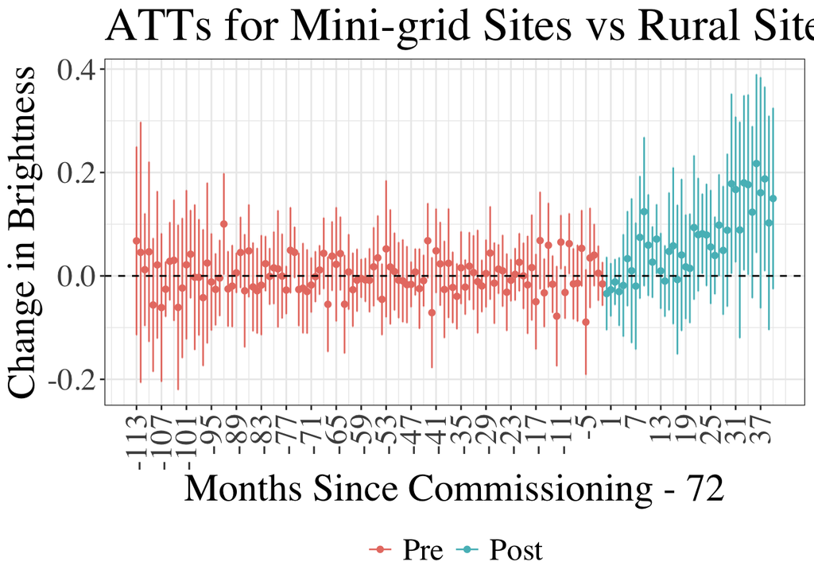

```r
# plot group-time ATTs
did_control_agg_plt <- ggdid(did_control_agg, xgap = 6) +
    labs(title = "ATTs for Mini-grid Sites vs Rural Sites with 72-Month Lag", x = "Months Since Commissioning - 72", y = "Change in Brightness") +
    theme_bw() + theme(axis.text.x = element_text(angle = 90, vjust = 0.5, hjust = 1)) +
    theme(text = element_text(size = 24, family = "serif"), legend.position = "bottom")
ggsave("figures/dark_africa/did_control_agg_plt_minigrid_rural_lag72_wide.png", did_control_agg_plt, width = 16, height = 6, units = "in", dpi = 300)


print(did_control_agg_plt)
```

## Compile a Table of the Aggregated Results

```r
# read in the data
did_control_agg_minigrid_ocean <- readRDS("data/dark_africa/did_control_agg_minigrid_ocean.rds")
did_control_agg_minigrid_desert <- readRDS("data/dark_africa/did_control_agg_minigrid_desert.rds")
did_control_agg_minigrid_jungle <- readRDS("data/dark_africa/did_control_agg_minigrid_jungle.rds")
did_control_agg_minigrid_rural <- readRDS("data/dark_africa/did_control_agg_minigrid_rural.rds")
did_control_agg_minigrid_built <- readRDS("data/dark_africa/did_control_agg_minigrid_built.rds")
did_nyt_agg_minigrid <- readRDS("data/dark_africa/did_nyt_agg_minigrid.rds")

# print out summaries of each
summary(did_control_agg_minigrid_ocean)
```

```
##
## Call:
## aggte(MP = did_control, type = "dynamic", na.rm = TRUE)
##
## Reference: Callaway, Brantly and Pedro H.C. Sant'Anna.  "Difference-in-Differences with Multiple Time Periods." Journal of Econometrics, Vol. 225, No. 2, pp. 200-230, 2021. <https://doi.org/10.1016/j.jeconom.2020.12.001>, <https://arxiv.org/abs/1803.09015>
##
##
## Overall summary of ATT's based on event-study/dynamic aggregation:
##      ATT    Std. Error     [ 95%  Conf. Int.]
##  -0.0129        0.0175    -0.0473      0.0215
##
##
## Dynamic Effects:
##  Event time Estimate Std. Error [95% Simult.  Conf. Band]
##         -77   0.0361     0.0066        0.0159      0.0562 *
##         -76   0.0007     0.0752       -0.2274      0.2288
##         -75   0.0567     0.0314       -0.0386      0.1520
##         -74   0.1039     0.0070        0.0828      0.1250 *
##         -73  -0.1034     0.0185       -0.1595     -0.0474 *
##         -72  -0.0159     0.0174       -0.0687      0.0370
##         -71   0.0101     0.0037       -0.0010      0.0212
##         -70  -0.0784     0.0964       -0.3708      0.2139
##         -69   0.0366     0.0267       -0.0445      0.1177
##         -68  -0.0063     0.0068       -0.0270      0.0144
##         -67  -0.0633     0.0485       -0.2104      0.0838
##         -66   0.0265     0.0203       -0.0351      0.0881
##         -65   0.0549     0.0130        0.0155      0.0943 *
##         -64   0.0294     0.0247       -0.0455      0.1044
##         -63  -0.0332     0.0588       -0.2114      0.1450
##         -62   0.0103     0.0363       -0.0997      0.1203
##         -61   0.0127     0.0744       -0.2129      0.2383
##         -60  -0.0409     0.0701       -0.2535      0.1717
##         -59   0.0212     0.0451       -0.1155      0.1579
##         -58  -0.0617     0.0264       -0.1419      0.0185
##         -57  -0.0125     0.0329       -0.1124      0.0875
##         -56   0.0281     0.0391       -0.0904      0.1467
##         -55  -0.0123     0.0165       -0.0623      0.0377
##         -54   0.0793     0.0416       -0.0470      0.2056
##         -53   0.0410     0.0191       -0.0169      0.0988
##         -52  -0.0924     0.0116       -0.1274     -0.0573 *
```

[output cut: 154 more lines]

```
##         103   0.1304     0.0504       -0.0224      0.2833
##         104  -0.0275     0.0725       -0.2474      0.1923
##         105   0.1038     0.0639       -0.0900      0.2977
##         106   0.2195     0.0744       -0.0063      0.4453
##         107   0.1554     0.0597       -0.0257      0.3366
##         108   0.2429     0.0684        0.0355      0.4504 *
##         109   0.1790     0.0703       -0.0343      0.3922
##         110   0.1004     0.0633       -0.0917      0.2925
##         111   0.1258     0.0711       -0.0897      0.3413
##         112   0.1116     0.0545       -0.0537      0.2770
## ---
## Signif. codes: `*' confidence band does not cover 0
##
## Control Group:  Never Treated,  Anticipation Periods:  0
## Estimation Method:  Doubly Robust
```

```r
summary(did_control_agg_minigrid_desert)
```

```
##
## Call:
## aggte(MP = did_control, type = "dynamic", na.rm = TRUE)
##
## Reference: Callaway, Brantly and Pedro H.C. Sant'Anna.  "Difference-in-Differences with Multiple Time Periods." Journal of Econometrics, Vol. 225, No. 2, pp. 200-230, 2021. <https://doi.org/10.1016/j.jeconom.2020.12.001>, <https://arxiv.org/abs/1803.09015>
##
##
## Overall summary of ATT's based on event-study/dynamic aggregation:
##    ATT    Std. Error     [ 95%  Conf. Int.]
##  0.034        0.0188    -0.0029       0.071
##
##
## Dynamic Effects:
##  Event time Estimate Std. Error [95% Simult.  Conf. Band]
##         -77  -0.0008     0.0081       -0.0255      0.0239
##         -76   0.0940     0.1456       -0.3503      0.5383
##         -75  -0.0673     0.0024       -0.0744     -0.0601 *
##         -74  -0.0045     0.0776       -0.2414      0.2324
##         -73  -0.0072     0.0320       -0.1048      0.0905
##         -72   0.0175     0.0159       -0.0309      0.0659
##         -71  -0.0067     0.0030       -0.0159      0.0025
##         -70  -0.1137     0.0514       -0.2706      0.0433
##         -69  -0.0345     0.0172       -0.0868      0.0179
##         -68   0.1781     0.0236        0.1061      0.2502 *
##         -67  -0.1590     0.0277       -0.2437     -0.0744 *
##         -66   0.0699     0.0198        0.0094      0.1304 *
##         -65   0.0287     0.0173       -0.0241      0.0814
##         -64   0.0973     0.0305        0.0043      0.1902 *
##         -63  -0.1515     0.0594       -0.3328      0.0298
##         -62  -0.0821     0.0363       -0.1928      0.0285
##         -61   0.0983     0.0744       -0.1286      0.3253
##         -60  -0.0051     0.0711       -0.2221      0.2120
##         -59   0.0086     0.0389       -0.1103      0.1274
##         -58  -0.0691     0.0235       -0.1408      0.0026
##         -57  -0.0735     0.0333       -0.1752      0.0283
##         -56   0.1600     0.0546       -0.0065      0.3265
##         -55  -0.0888     0.0163       -0.1386     -0.0389 *
##         -54   0.1248     0.0422       -0.0039      0.2535
##         -53   0.0075     0.0201       -0.0539      0.0689
##         -52  -0.0069     0.0113       -0.0416      0.0277
```

[output cut: 154 more lines]

```
##         103   0.1738     0.0514        0.0170      0.3305 *
##         104   0.1172     0.0680       -0.0902      0.3246
##         105   0.1356     0.0632       -0.0574      0.3286
##         106   0.0973     0.0700       -0.1163      0.3109
##         107   0.0702     0.0565       -0.1022      0.2426
##         108   0.2611     0.0632        0.0682      0.4540 *
##         109   0.1609     0.0697       -0.0520      0.3737
##         110   0.2020     0.0633        0.0088      0.3952 *
##         111   0.1132     0.0681       -0.0946      0.3210
##         112   0.1114     0.0539       -0.0532      0.2760
## ---
## Signif. codes: `*' confidence band does not cover 0
##
## Control Group:  Never Treated,  Anticipation Periods:  0
## Estimation Method:  Doubly Robust
```

```r
summary(did_control_agg_minigrid_jungle)
```

```
##
## Call:
## aggte(MP = did_control, type = "dynamic", na.rm = TRUE)
##
## Reference: Callaway, Brantly and Pedro H.C. Sant'Anna.  "Difference-in-Differences with Multiple Time Periods." Journal of Econometrics, Vol. 225, No. 2, pp. 200-230, 2021. <https://doi.org/10.1016/j.jeconom.2020.12.001>, <https://arxiv.org/abs/1803.09015>
##
##
## Overall summary of ATT's based on event-study/dynamic aggregation:
##     ATT    Std. Error     [ 95%  Conf. Int.]
##  0.0232         0.018     -0.012      0.0584
##
##
## Dynamic Effects:
##  Event time Estimate Std. Error [95% Simult.  Conf. Band]
##         -77   0.0745     0.0088        0.0477      0.1013 *
##         -76  -0.0014     0.0748       -0.2301      0.2274
##         -75   0.0912     0.0337       -0.0117      0.1941
##         -74   0.0359     0.0786       -0.2044      0.2763
##         -73  -0.0820     0.0181       -0.1375     -0.0265 *
##         -72   0.0051     0.0159       -0.0436      0.0538
##         -71  -0.0025     0.0037       -0.0138      0.0088
##         -70  -0.0668     0.0502       -0.2204      0.0867
##         -69  -0.0161     0.0176       -0.0699      0.0377
##         -68   0.0082     0.0365       -0.1035      0.1199
##         -67  -0.0325     0.0287       -0.1203      0.0553
##         -66   0.0626     0.0207       -0.0006      0.1259
##         -65   0.0712     0.0122        0.0338      0.1085 *
##         -64   0.0168     0.0264       -0.0640      0.0976
##         -63   0.0147     0.0623       -0.1756      0.2050
##         -62  -0.0571     0.0349       -0.1637      0.0495
##         -61   0.0337     0.0722       -0.1871      0.2545
##         -60  -0.0237     0.0720       -0.2438      0.1964
##         -59   0.0144     0.0417       -0.1130      0.1419
##         -58  -0.0431     0.0251       -0.1199      0.0337
##         -57  -0.0660     0.0334       -0.1680      0.0361
##         -56   0.0450     0.0421       -0.0838      0.1737
##         -55   0.0091     0.0195       -0.0506      0.0688
##         -54   0.1285     0.0419        0.0005      0.2565 *
##         -53   0.0708     0.0190        0.0126      0.1289 *
##         -52  -0.0973     0.0128       -0.1365     -0.0582 *
```

[output cut: 154 more lines]

```
##         103   0.2839     0.0515        0.1265      0.4414 *
##         104   0.1189     0.0714       -0.0994      0.3371
##         105   0.1232     0.0641       -0.0728      0.3192
##         106   0.2131     0.0746       -0.0151      0.4412
##         107   0.2017     0.0586        0.0225      0.3809 *
##         108   0.2249     0.0650        0.0263      0.4236 *
##         109   0.1411     0.0737       -0.0840      0.3662
##         110   0.2007     0.0679       -0.0067      0.4082
##         111   0.1731     0.0711       -0.0441      0.3903
##         112   0.3089     0.0547        0.1419      0.4760 *
## ---
## Signif. codes: `*' confidence band does not cover 0
##
## Control Group:  Never Treated,  Anticipation Periods:  0
## Estimation Method:  Doubly Robust
```

```r
summary(did_control_agg_minigrid_rural)
```

```
##
## Call:
## aggte(MP = did_control, type = "dynamic", na.rm = TRUE)
##
## Reference: Callaway, Brantly and Pedro H.C. Sant'Anna.  "Difference-in-Differences with Multiple Time Periods." Journal of Econometrics, Vol. 225, No. 2, pp. 200-230, 2021. <https://doi.org/10.1016/j.jeconom.2020.12.001>, <https://arxiv.org/abs/1803.09015>
##
##
## Overall summary of ATT's based on event-study/dynamic aggregation:
##     ATT    Std. Error     [ 95%  Conf. Int.]
##  0.0421        0.0263    -0.0095      0.0937
##
##
## Dynamic Effects:
##  Event time Estimate Std. Error [95% Simult.  Conf. Band]
##         -77   0.0419     0.0377       -0.2126      0.2965
##         -76   0.1009     0.0734       -0.3951      0.5968
##         -75   0.0202     0.0316       -0.1935      0.2339
##         -74   0.0248     0.0301       -0.1784      0.2280
##         -73  -0.1091     0.0510       -0.4539      0.2357
##         -72   0.0385     0.0561       -0.3403      0.4174
##         -71  -0.0347     0.0558       -0.4115      0.3421
##         -70  -0.0674     0.0921       -0.6900      0.5552
##         -69   0.0042     0.0278       -0.1839      0.1923
##         -68   0.0710     0.0247       -0.0957      0.2377
##         -67  -0.0723     0.0304       -0.2780      0.1333
##         -66   0.0298     0.0205       -0.1088      0.1683
##         -65   0.0525     0.0228       -0.1017      0.2067
##         -64   0.1112     0.0352       -0.1265      0.3489
##         -63  -0.0538     0.0598       -0.4578      0.3502
##         -62  -0.0656     0.0374       -0.3180      0.1868
##         -61   0.0019     0.0850       -0.5726      0.5764
##         -60   0.0134     0.0714       -0.4693      0.4961
##         -59  -0.0178     0.0534       -0.3790      0.3433
##         -58  -0.0364     0.0225       -0.1881      0.1153
##         -57  -0.0470     0.0339       -0.2763      0.1823
##         -56   0.0869     0.0392       -0.1779      0.3517
##         -55  -0.0142     0.0183       -0.1377      0.1094
##         -54   0.0812     0.0435       -0.2127      0.3751
##         -53   0.0438     0.0319       -0.1720      0.2596
##         -52   0.0019     0.0304       -0.2034      0.2073
```

[output cut: 154 more lines]

```
##         103   0.2173     0.0646       -0.2193      0.6539
##         104   0.1456     0.0748       -0.3600      0.6513
##         105   0.2391     0.0872       -0.3500      0.8283
##         106   0.2175     0.0874       -0.3729      0.8078
##         107   0.1922     0.0838       -0.3742      0.7587
##         108   0.2720     0.0852       -0.3039      0.8480
##         109   0.2145     0.0883       -0.3820      0.8110
##         110   0.2385     0.0706       -0.2389      0.7159
##         111   0.1594     0.0748       -0.3463      0.6652
##         112   0.2092     0.0633       -0.2185      0.6370
## ---
## Signif. codes: `*' confidence band does not cover 0
##
## Control Group:  Never Treated,  Anticipation Periods:  0
## Estimation Method:  Doubly Robust
```

```r
summary(did_control_agg_minigrid_built)
```

```
##
## Call:
## aggte(MP = did_control, type = "dynamic", na.rm = TRUE)
##
## Reference: Callaway, Brantly and Pedro H.C. Sant'Anna.  "Difference-in-Differences with Multiple Time Periods." Journal of Econometrics, Vol. 225, No. 2, pp. 200-230, 2021. <https://doi.org/10.1016/j.jeconom.2020.12.001>, <https://arxiv.org/abs/1803.09015>
##
##
## Overall summary of ATT's based on event-study/dynamic aggregation:
##      ATT    Std. Error     [ 95%  Conf. Int.]
##  -0.8998        0.1225      -1.14     -0.6596 *
##
##
## Dynamic Effects:
##  Event time Estimate Std. Error [95% Simult.  Conf. Band]
##         -77   0.0918     0.1038       -0.2536      0.4373
##         -76   0.4088     0.1340       -0.0369      0.8544
##         -75  -0.4885     0.0993       -0.8187     -0.1583 *
##         -74  -0.1253     0.1163       -0.5121      0.2616
##         -73  -0.2351     0.0869       -0.5243      0.0541
##         -72   0.2760     0.0660        0.0566      0.4954 *
##         -71   0.1860     0.0747       -0.0623      0.4343
##         -70  -0.0632     0.0915       -0.3676      0.2411
##         -69  -0.4747     0.0937       -0.7865     -0.1630 *
##         -68  -0.1039     0.1133       -0.4806      0.2729
##         -67   0.0929     0.1336       -0.3516      0.5374
##         -66   0.1231     0.1144       -0.2574      0.5036
##         -65   0.1063     0.0877       -0.1855      0.3980
##         -64   0.3867     0.0985        0.0589      0.7145 *
##         -63  -0.4637     0.1193       -0.8605     -0.0670 *
##         -62  -0.2133     0.0734       -0.4575      0.0309
##         -61  -0.1204     0.1014       -0.4578      0.2170
##         -60   0.2638     0.0936       -0.0476      0.5751
##         -59   0.1780     0.0753       -0.0724      0.4285
##         -58  -0.0784     0.0748       -0.3273      0.1705
##         -57  -0.4476     0.1022       -0.7874     -0.1077 *
##         -56  -0.1269     0.1046       -0.4749      0.2211
##         -55   0.1058     0.1117       -0.2659      0.4775
##         -54   0.2107     0.1097       -0.1543      0.5757
##         -53   0.0965     0.0956       -0.2215      0.4145
##         -52   0.2987     0.0936       -0.0127      0.6100
```

[output cut: 154 more lines]

```
##         103  -0.8207     0.1976       -1.4781     -0.1633 *
##         104  -1.8654     0.2607       -2.7326     -0.9983 *
##         105  -1.6528     0.2247       -2.4002     -0.9054 *
##         106  -1.1138     0.2319       -1.8853     -0.3423 *
##         107  -1.4404     0.2053       -2.1235     -0.7574 *
##         108  -1.2958     0.2204       -2.0290     -0.5625 *
##         109  -0.8448     0.2218       -1.5827     -0.1069 *
##         110  -0.9942     0.2053       -1.6772     -0.3113 *
##         111  -1.5833     0.2261       -2.3355     -0.8311 *
##         112  -1.6121     0.2656       -2.4957     -0.7285 *
## ---
## Signif. codes: `*' confidence band does not cover 0
##
## Control Group:  Never Treated,  Anticipation Periods:  0
## Estimation Method:  Doubly Robust
```

```r
summary(did_nyt_agg_minigrid)
```

```
##
## Call:
## aggte(MP = did_nyt, type = "dynamic", na.rm = TRUE)
##
## Reference: Callaway, Brantly and Pedro H.C. Sant'Anna.  "Difference-in-Differences with Multiple Time Periods." Journal of Econometrics, Vol. 225, No. 2, pp. 200-230, 2021. <https://doi.org/10.1016/j.jeconom.2020.12.001>, <https://arxiv.org/abs/1803.09015>
##
##
## Overall summary of ATT's based on event-study/dynamic aggregation:
##      ATT    Std. Error     [ 95%  Conf. Int.]
##  -0.0573        0.0741    -0.2026       0.088
##
##
## Dynamic Effects:
##  Event time Estimate Std. Error [95% Simult.  Conf. Band]
##         -65   0.0161     0.0262       -0.0603      0.0925
##         -64   0.0981     0.0366       -0.0086      0.2048
##         -63  -0.1079     0.0670       -0.3030      0.0872
##         -62  -0.0899     0.0433       -0.2162      0.0364
##         -61   0.0387     0.0862       -0.2125      0.2899
##         -60   0.0345     0.0889       -0.2245      0.2934
##         -59   0.0162     0.0525       -0.1368      0.1693
##         -58  -0.0215     0.0314       -0.1131      0.0700
##         -57  -0.0918     0.0392       -0.2061      0.0224
##         -56   0.0423     0.0488       -0.1000      0.1845
##         -55   0.0195     0.0259       -0.0560      0.0950
##         -54   0.1228     0.0499       -0.0227      0.2683
##         -53   0.0157     0.0333       -0.0812      0.1126
##         -52  -0.0430     0.0291       -0.1279      0.0419
##         -51  -0.0014     0.0301       -0.0891      0.0862
##         -50   0.0948     0.0332       -0.0020      0.1916
##         -49  -0.0106     0.0269       -0.0889      0.0677
##         -48  -0.0572     0.0472       -0.1948      0.0804
##         -47   0.0288     0.0228       -0.0377      0.0952
##         -46   0.0084     0.0177       -0.0432      0.0599
##         -45   0.0109     0.0308       -0.0788      0.1006
##         -44   0.0057     0.0328       -0.0899      0.1013
##         -43  -0.0006     0.0425       -0.1245      0.1233
##         -42  -0.0512     0.0262       -0.1276      0.0251
##         -41   0.0286     0.0269       -0.0499      0.1071
##         -40  -0.0213     0.0422       -0.1444      0.1018
```

[output cut: 101 more lines]

```
##          62   0.0285     0.0531       -0.1261      0.1831
##          63   0.0912     0.0387       -0.0215      0.2040
##          64   0.1187     0.0366        0.0120      0.2254 *
##          65   0.0614     0.0779       -0.1657      0.2884
##          66   0.1225     0.0709       -0.0840      0.3290
##          67   0.0926     0.0402       -0.0245      0.2098
##          68   0.1085     0.0539       -0.0485      0.2656
##          69   0.0363     0.0631       -0.1474      0.2199
##          70   0.0720     0.0502       -0.0742      0.2182
##          71   0.0476     0.0366       -0.0591      0.1544
## ---
## Signif. codes: `*' confidence band does not cover 0
##
## Control Group:  Not Yet Treated,  Anticipation Periods:  0
## Estimation Method:  Doubly Robust
```

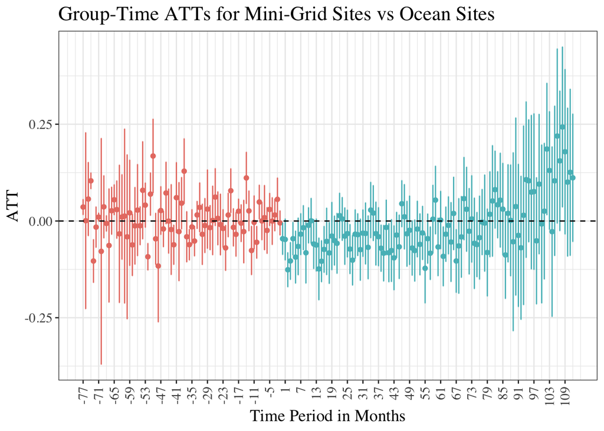

```r
# recreate the plots for each of these
did_nyt_agg_plt_minigrid <- ggdid(did_nyt_agg_minigrid, xgap = 6) +
    labs(title = "ATTs for Mini-grid Construction on Nighttime Brightness for 700+ Sites in Africa", x = "Months Since Commissioning", y = "Change in Brightness") +
    theme_bw() + theme(axis.text.x = element_text(angle = 90, vjust = 0.5, hjust = 1)) +
    theme(text = element_text(size = 24, family = "serif"), legend.position = "bottom")

did_nyt_agg_plt_minigrid_small <- ggdid(did_nyt_agg_minigrid, xgap = 6) +
    labs(title = "ATTs for Mini-grid Construction on Nighttime Brightness for 700+ Sites in Africa", x = "Months Since Commissioning", y = "Change in Brightness") +
    theme_bw() + theme(axis.text.x = element_text(angle = 90, vjust = 0.5, hjust = 1)) +
    theme(text = element_text(size = 14, family = "serif"), legend.position = "none")

did_control_agg_plt_minigrid_ocean <- ggdid(did_control_agg_minigrid_ocean, xgap = 6) +
    labs(title = "Group-Time ATTs for Mini-Grid Sites vs Ocean Sites", x = "Time Period in Months", y = "ATT") +
    theme_bw() + theme(axis.text.x = element_text(angle = 90, vjust = 0.5, hjust = 1)) +
    theme(text = element_text(size = 14, family = "serif"), legend.position = "none")

did_control_agg_plt_minigrid_desert <- ggdid(did_control_agg_minigrid_desert, xgap = 6) +
    labs(title = "Group-Time ATTs for Mini-Grid Sites vs Desert Sites", x = "Time Period in Months", y = "ATT") +
    theme_bw() + theme(axis.text.x = element_text(angle = 90, vjust = 0.5, hjust = 1)) +
    theme(text = element_text(size = 14, family = "serif"), legend.position = "none")

did_control_agg_plt_minigrid_jungle <- ggdid(did_control_agg_minigrid_jungle, xgap = 6) +
    labs(title = "Group-Time ATTs for Mini-Grid Sites vs Rainforest Sites", x = "Time Period in Months", y = "ATT") +
    theme_bw() + theme(axis.text.x = element_text(angle = 90, vjust = 0.5, hjust = 1)) +
    theme(text = element_text(size = 14, family = "serif"), legend.position = "none")

did_control_agg_plt_minigrid_rural <- ggdid(did_control_agg_minigrid_rural, xgap = 6) +
    labs(title = "Group-Time ATTs for Mini-Grid Sites vs Rural Sites", x = "Time Period in Months", y = "ATT") +
    theme_bw() + theme(axis.text.x = element_text(angle = 90, vjust = 0.5, hjust = 1)) +
    theme(text = element_text(size = 14, family = "serif"), legend.position = "none")

did_control_agg_plt_minigrid_built <- ggdid(did_control_agg_minigrid_built, xgap = 6) +
    labs(title = "Group-Time ATTs for Mini-Grid Sites vs Built Sites", x = "Time Period in Months", y = "ATT") +
    theme_bw() + theme(axis.text.x = element_text(angle = 90, vjust = 0.5, hjust = 1)) +
    theme(text = element_text(size = 14, family = "serif"), legend.position = "none")


# show them all
print(did_control_agg_plt_minigrid_ocean)
```

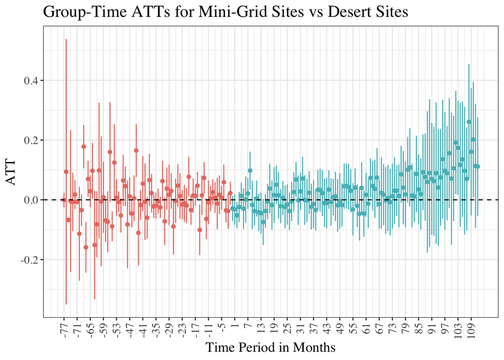

```r
print(did_control_agg_plt_minigrid_desert)
```

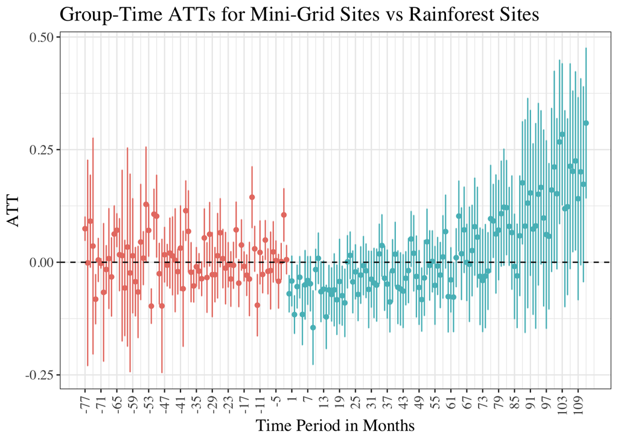

```r
print(did_control_agg_plt_minigrid_jungle)
```

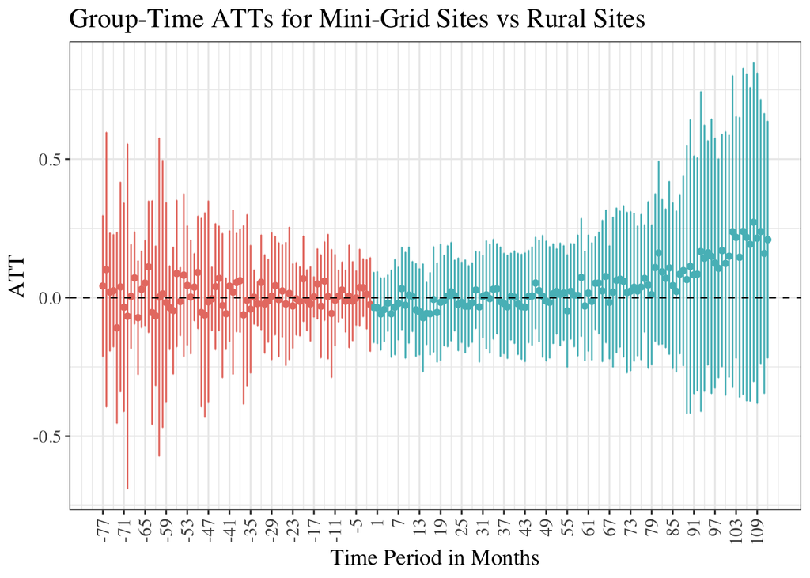

```r
print(did_control_agg_plt_minigrid_rural)
```

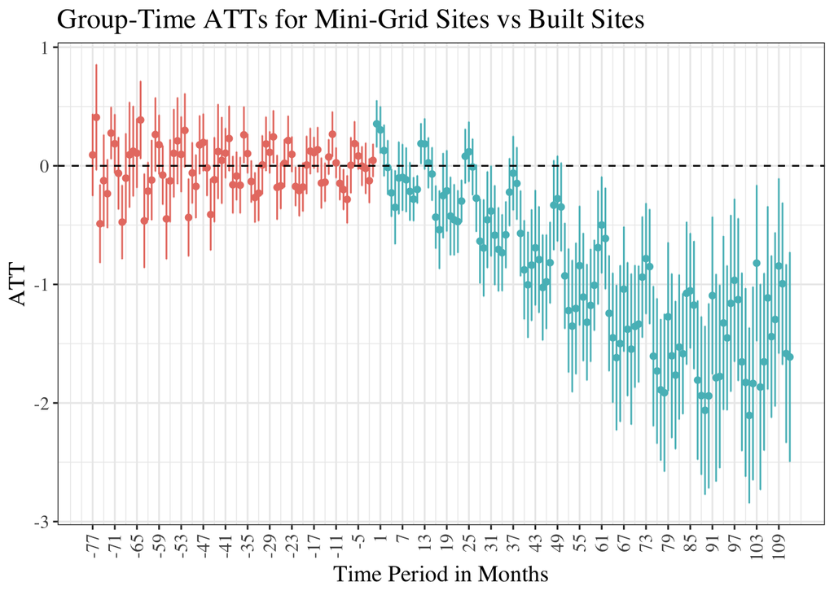

```r
print(did_control_agg_plt_minigrid_built)
```

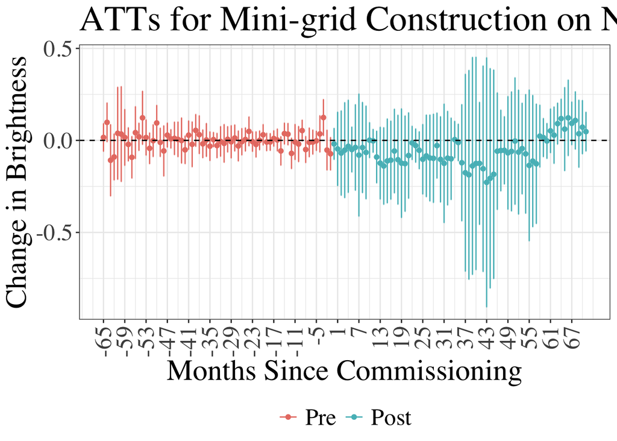

```r
print(did_nyt_agg_plt_minigrid)
```

```r
# export
ggsave("figures/dark_africa/did_nyt_agg_plt_minigrid.png", did_nyt_agg_plt_minigrid, width = 16, height = 10, units = "in", dpi = 300)
ggsave("figures/dark_africa/did_nyt_agg_plt_minigrid_small.png", did_nyt_agg_plt_minigrid_small, width = 6, height = 5, units = "in", dpi = 300)
ggsave("figures/dark_africa/did_control_agg_plt_minigrid_ocean.png", did_control_agg_plt_minigrid_ocean, width = 6, height = 5, units = "in", dpi = 300)
ggsave("figures/dark_africa/did_control_agg_plt_minigrid_desert.png", did_control_agg_plt_minigrid_desert, width = 6, height = 5, units = "in", dpi = 300)
ggsave("figures/dark_africa/did_control_agg_plt_minigrid_jungle.png", did_control_agg_plt_minigrid_jungle, width = 6, height = 5, units = "in", dpi = 300)
ggsave("figures/dark_africa/did_control_agg_plt_minigrid_rural.png", did_control_agg_plt_minigrid_rural, width = 6, height = 5, units = "in", dpi = 300)
ggsave("figures/dark_africa/did_control_agg_plt_minigrid_built.png", did_control_agg_plt_minigrid_built, width = 6, height = 5, units = "in", dpi = 300)

# for presentation
# ggsave("figures/dark_africa/did_nyt_agg_plt_minigrid_hires.png", did_nyt_agg_plt_minigrid, width = 12, height = 6, units = "in", dpi = 300)
```

## Results

| Comparison | ATT | Std. Error | 95% CI (Lower) | 95% CI (Upper) | Sig. |
| --- | --- | --- | --- | --- | --- |
| Mini-Grid vs Ocean | -0.0129 | 0.0175 | -0.0473 | 0.0215 |  |
| Mini-Grid vs Desert | 0.0340 | 0.0188 | -0.0029 | 0.0710 |  |
| Mini-Grid vs Jungle | 0.0232 | 0.0180 | -0.0120 | 0.0584 |  |
| Mini-Grid vs Rural | 0.0421 | 0.0263 | -0.0095 | 0.0937 |  |
| Mini-Grid vs Built | -0.8998 | 0.1225 | -1.1400 | -0.6596 | * |
| Mini-Grid vs Not Yet Treated | -0.0573 | 0.0741 | -0.2026 | 0.0880 |  |

## Interpretation and Conclusions

In this notebook, we have conducted a Difference in Difference analysis using the Callaway & Sant’Anna (2020) method for staggered treatment timing. We compared the nighttime lights values of mini-grid sites to various control site types, including ocean, desert, jungle, rural, and built areas. The results indicate that mini-grid sites show a statistically significant decrease in brightness compared to built areas, while comparisons with ocean, desert, jungle, and rural areas did not yield statistically significant differences. This suggests that mini-grid installations may not lead to substantial increases in nighttime brightness when compared to less developed areas, but they do show a significant difference when compared to already developed built areas. Further research could explore the underlying factors contributing to these differences and assess the broader impacts of mini-grid installations on local communities and environments.

## Further Reading

This analysis was the foundation of my Master’s thesis, which is currently under review for publication. The full thesis can be found [here](https://www.proquest.com/openview/93004cb28d4b39c798e019368d046f1d/1?pq-origsite=gscholar&cbl=18750&diss=y).